# Assignment3

Author

YangXu

## Read in the data

```r
library(forcats)
library(tidytext)
library(dplyr)
library(ggplot2)
library(data.table)
library(tidyr)
library(DT)
if (!file.exists("pubmed.csv"))
  download.file(
    url = "https://raw.githubusercontent.com/USCbiostats/data-science-data/master/03_pubmed/pubmed.csv",
    destfile = "pubmed.csv",
    method   = "libcurl",
    timeout  = 60
    )
pubmed <- read.csv("pubmed.csv")
```

# Question 1

#### Tokenize the abstracts and count the number of each token. Do you see anything interesting? Does removing stop words change what tokens appear as the most frequent? What are the 5 most common tokens for each search term after removing stopwords?

```r
# Tokenize the abstracts and count the number of each token
# Then sort by counts
pubmed %>%
  unnest_tokens(token,abstract) %>%
  count(token,sort = TRUE) %>%
  top_n(10,n)
```

```
   token     n
1    the 28126
2     of 24760
3    and 19993
4     in 14653
5     to 10920
6      a  8245
7   with  8038
8  covid  7275
9     19  7080
10    is  5649
```

#### Checked the 10 most frequently occurring words in the abstract. Most of these 10 words did not provide useful information such as ‘the’, ‘of’, ‘and’. But there were two relatively meaningful words, ‘covid’ and ‘19’.

```r
# Removing stop words and search top 5 common words for each term
# Get all terms of pubmed
table(pubmed$term)
```

```
          covid cystic fibrosis      meningitis    preeclampsia prostate cancer
            981             376             317             780             787
```

```r
# For term of 'covid'
pubmed %>%
  filter(term == 'covid') %>%
  unnest_tokens(token,abstract) %>%
  anti_join(stop_words, by = c("token" = "word")) %>%
  count(term,token,sort = TRUE) %>%
  top_n(5,n)
```

```
   term    token    n
1 covid    covid 7275
2 covid       19 7035
3 covid patients 2293
4 covid  disease  943
5 covid pandemic  800
```

#### In term of ‘covid’, the 5 most common tokens were ‘covid’, ‘19’, ‘patients’, ‘disease’ and ‘pandemic’.

```r
# For term of 'cystic fibrosis'
pubmed %>%
  filter(term == 'cystic fibrosis') %>%
  unnest_tokens(token,abstract) %>%
  anti_join(stop_words, by = c("token" = "word")) %>%
  count(term,token,sort = TRUE) %>%
  top_n(5,n)
```

```
             term    token   n
1 cystic fibrosis fibrosis 867
2 cystic fibrosis   cystic 862
3 cystic fibrosis       cf 625
4 cystic fibrosis patients 586
5 cystic fibrosis  disease 400
```

#### In term of ‘cystic fibrosis’, the 5 most common tokens were ‘fibrosis’, ‘cycstic’, ‘cf’, ‘patients’ and ‘disease’.

```r
# For term of 'meningitis'
pubmed %>%
  filter(term == 'meningitis') %>%
  unnest_tokens(token,abstract) %>%
  anti_join(stop_words, by = c("token" = "word")) %>%
  count(term,token,sort = TRUE) %>%
  top_n(5,n)
```

```
        term      token   n
1 meningitis   patients 446
2 meningitis meningitis 429
3 meningitis  meningeal 219
4 meningitis        csf 206
5 meningitis   clinical 187
```

#### In term of ‘meningitis’, the 5 most common tokens were ‘patients’, ‘meningitis’, ‘meningeal’, ‘csf’ and ‘cilinical’.

```r
# For term of 'preeclampsia'
pubmed %>%
  filter(term == 'preeclampsia') %>%
  unnest_tokens(token,abstract) %>%
  anti_join(stop_words, by = c("token" = "word")) %>%
  count(term,token,sort = TRUE) %>%
  top_n(5,n)
```

```
          term        token    n
1 preeclampsia          pre 2038
2 preeclampsia    eclampsia 2005
3 preeclampsia preeclampsia 1863
4 preeclampsia        women 1196
5 preeclampsia    pregnancy  969
```

#### In term of ‘preeclampsia’, the 5 most common tokens were ‘pre’, ‘eclampsia’, ‘preeclampsia’, ‘women’ and ‘pregnancy’.

```r
# For term of 'prostate cancer'
pubmed %>%
  filter(term == 'prostate cancer') %>%
  unnest_tokens(token,abstract) %>%
  anti_join(stop_words, by = c("token" = "word")) %>%
  count(term,token,sort = TRUE) %>%
  top_n(5,n)
```

```
             term     token    n
1 prostate cancer    cancer 3840
2 prostate cancer  prostate 3832
3 prostate cancer  patients  934
4 prostate cancer treatment  926
5 prostate cancer   disease  652
```

#### In term of ‘prostate cancer’, the 5 most common tokens were ‘cancer’, ‘prostate’, ‘patients’, ‘treatment’ and ‘disease’.

# Question 2

#### Tokenize the abstracts into bigrams. Find the 10 most common bigrams and visualize them with ggplot2.

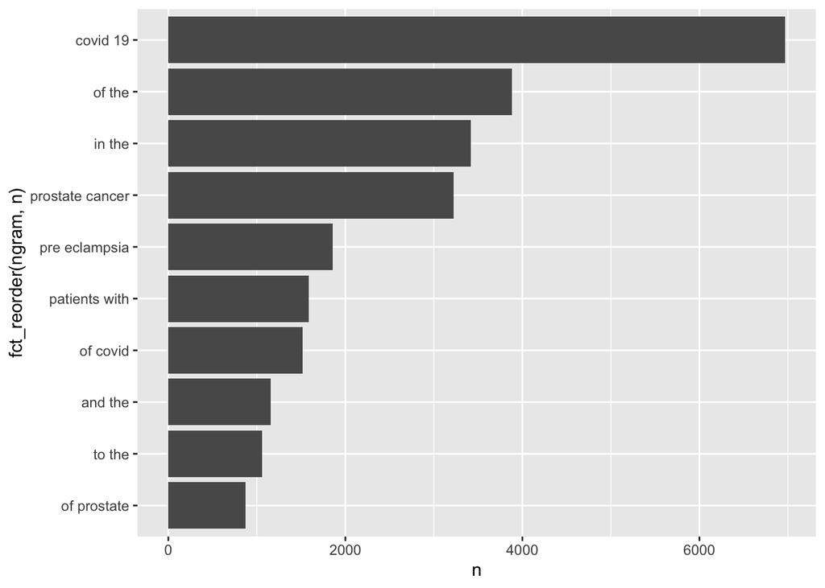

```r
pubmed %>%
   unnest_ngrams(ngram, abstract, n = 2) %>%
  anti_join(stop_words, by = c("ngram" = "word")) %>%
 count(ngram, sort = T) %>%
 top_n(10,n) %>%
 ggplot(aes(n, fct_reorder(ngram, n)))+
 geom_col()
```

#### Above were the 10 most common bigrams in the abstracts. But some of bigrams only consist of stopwords. So next we removed stopwords.

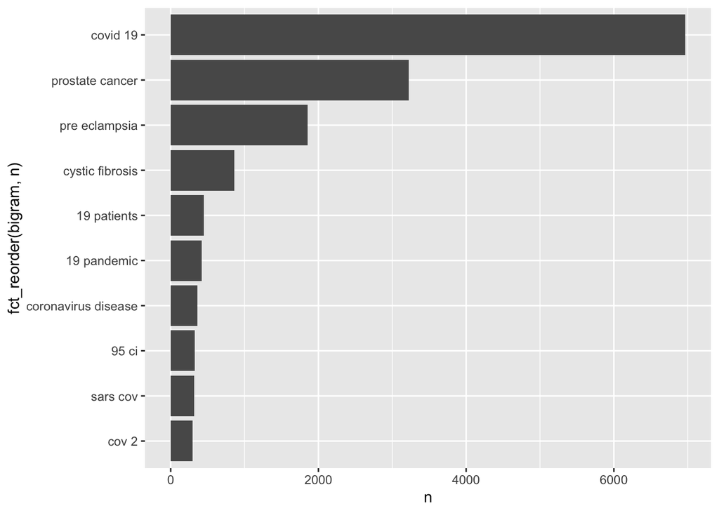

```r
# Remove stopwords
pubmed %>%
  unnest_tokens(bigram, abstract, token = 'ngrams', n = 2) %>%
  separate(bigram, into = c("word1", "word2"), sep = " ") %>%
  filter(!word1 %in% stop_words$word, !word2 %in% stop_words$word) %>%
  unite(bigram, word1, word2, sep = " ") %>%
  count(bigram, sort = TRUE) %>%
  top_n(10, n) %>%
  ggplot(aes(n, fct_reorder(bigram, n)))+
 geom_col()
```

#### Above were the 10 most common bigrams without stopwords in the abstracts.

# Question 3

#### Calculate the TF-IDF value for each word-search term combination (here you want the search term to be the “document”). What are the 5 tokens from each search term with the highest TF-IDF value? How are the results different from the answers you got in question 1?

```r
# Here we still remove stopwords from our search
pubmed_tf_idf <- pubmed %>%
  unnest_tokens(words,abstract) %>%
  anti_join(stop_words, by = c("words" = "word")) %>%
  count(words, term) %>%
  group_by(term)%>%
  bind_tf_idf(words, term, n) %>%
  top_n(5, n) %>%
  arrange(desc(tf_idf))

datatable(pubmed_tf_idf, options = list(pageLength = 5))
```

|  | words | term | n | tf | idf | tf_idf |
| --- | --- | --- | --- | --- | --- | --- |
| 1 | covid | covid | 7275 | 0.06469196841431316 | 1.6094379124341 | 0.1041177065959849 |
| 2 | prostate | prostate cancer | 3832 | 0.05629499045100632 | 1.6094379124341 | 0.09060329191196521 |
| 3 | eclampsia | preeclampsia | 2005 | 0.02552676809472277 | 1.6094379124341 | 0.04108374835356001 |
| 4 | preeclampsia | preeclampsia | 1863 | 0.02371888726207906 | 1.6094379124341 | 0.0381740764003403 |
| 5 | meningitis | meningitis | 429 | 0.01639594878654691 | 1.6094379124341 | 0.02638826158739649 |
| 6 | cf | cystic fibrosis | 625 | 0.02341262408690766 | 0.9162907318741551 | 0.02145277045968709 |
| 7 | fibrosis | cystic fibrosis | 867 | 0.03247799213335831 | 0.5108256237659907 | 0.0165905905901897 |
| 8 | cystic | cystic fibrosis | 862 | 0.03229069114066305 | 0.5108256237659907 | 0.01649491244376415 |
| 9 | meningeal | meningitis | 219 | 0.008369959870055418 | 1.6094379124341 | 0.01347093074041919 |
| 10 | pandemic | covid | 800 | 0.007113893433876361 | 1.6094379124341 | 0.01144936979749662 |

[output cut: 15 more lines]